# Expected_Values.R

Tejus

12/09/2020

## Statistical Inference

The process of making conclusions about populations from noisy data (that we’re assuming was drawn from that population).

Way to go : Assume that the population & the randomness governing our sample can be given by densities and mass functions.

We can work with characteristics of these densities & mass functions instead of the whole function.

Most useful characterizations :

- **Expected Values** Or **Mean** : Characterization of it’s center (Idea of physical center of mass).
- **Variance** : Characterization of spread of data.
- **Sample Quantiles**

**The above characterizations are used to estimate the same characters for population versions.**  
Eg. Sample mean will estimate population mean, sample variance estimates population variance and so on.

## Population Mean

- The **expected value** or **mean** of a random variable is the center of its distribution. (Balances data points on both sides)
- For discrete random variable $X$ with PMF $p(x)$, it is defined as follows
  $$E[X] = \sum_x xp(x)$$
  where the sum is taken over the possible values of $x$
- $E[X]$ represents the center of mass of a collection of locations and weights, $\{x, p(x)\}$

## Sample Mean

- Sample Mean is an estimate of **Population Mean**.
- Sample Mean is the center of mass if we treat each data point as equally likely i.e, $p(x_i) = 1/n$ .
- The center of mass of the data is the empirical mean
  $$\bar X = \sum_{i=1}^n x_i p(x_i)$$
  where $p(x_i) = 1/n$

In above case
$$\bar X$$
is equal to our center of mass.

## Example of sample mean

#### Finding the center of mass of these bars.

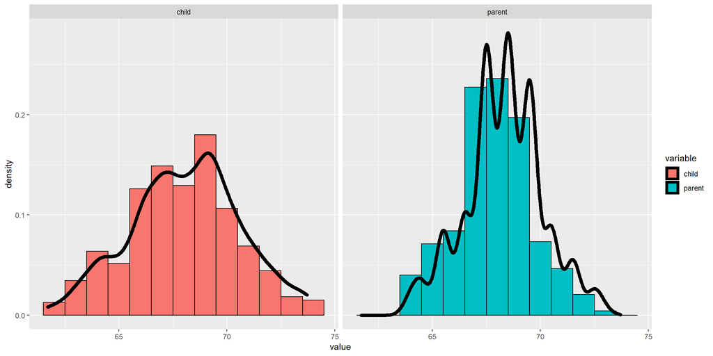

```r
library(ggplot2)
library(reshape2)
longGalton <- melt(galton, measure.vars = c("child", "parent"))
g <- ggplot(longGalton, aes(x = value)) + geom_histogram(aes(y = ..density..,  fill = variable), binwidth=1, colour = "black") + geom_density(size = 2)
g <- g + facet_grid(. ~ variable)
g
```

### Using Manipulate

Manipulating the vertical line (adjusting the mean) and minimizing the MSE (Mean squared error) we got the mean at
$$\mu = 68$$
which gives minimum MSE.

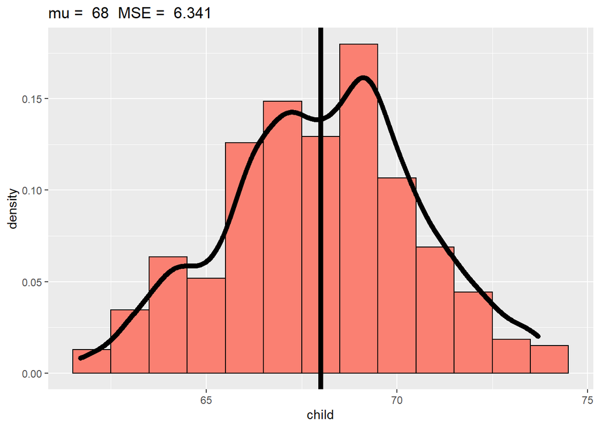

## Example of Population Mean

- Suppose a coin is flipped and $X$ is declared $0$ or $1$ corresponding to a head or a tail, respectively
- What is the expected value of $X$?
  $$E[X] = .5 \times 0 + .5 \times 1 = .5$$
- Note, if thought about geometrically, this answer is obvious; if two equal weights are spaced at 0 and 1, the center of mass will be $.5$

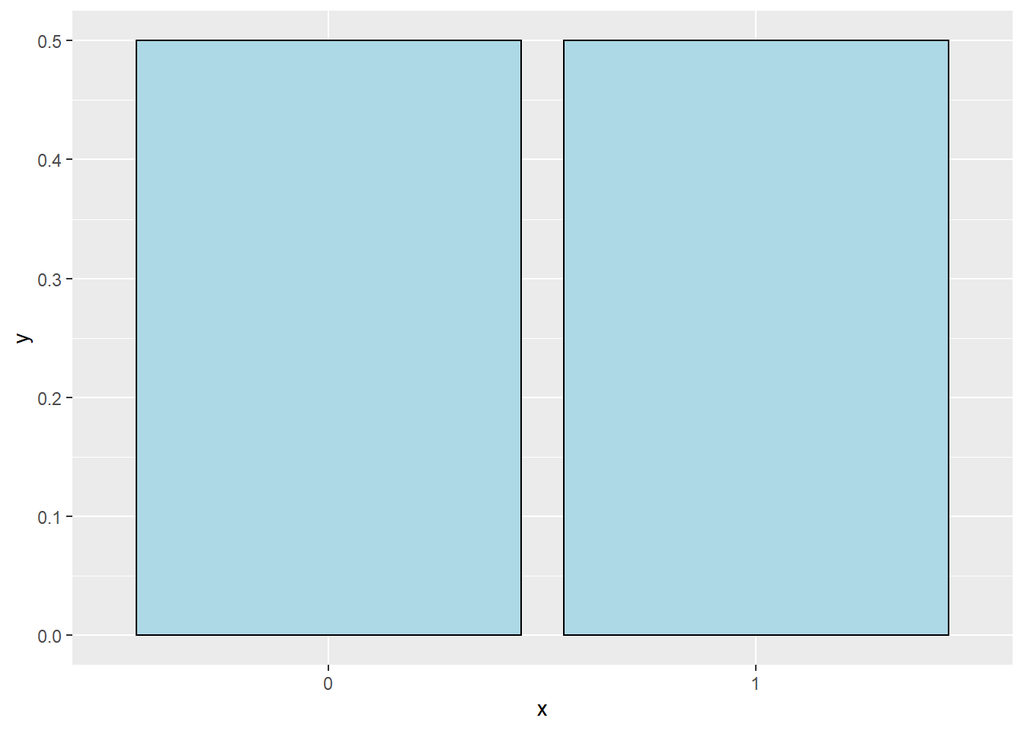

## Continuous random variables

- For a continuous random variable, $X$, with density, $f$, the expected value is again exactly the center of mass of the density

## Facts about expected values

- Recall that expected values are properties of distributions
- Note the average of random variables is itself a random variable (That means it also has a distribution. One could repeatedly sample from this distribution) and its associated distribution has an expected value
- **The center of this distribution is the same as that of the original distribution**
- Therefore, the expected value of the **sample mean** is the population mean that it’s trying to estimate. (They overlap at mean; Ideal case we want)
- When the expected value of an estimator is what its trying to estimate, we say that the estimator is **unbiased**

## Sumarizing what we know

- Expected values are properties of distributions
- The population mean is the center of mass of population
- The sample mean is the center of mass of the observed data
- The sample mean is an estimate of the population mean
- The sample mean is unbiased
  - The population mean of its distribution is the mean that it’s trying to estimate. (We don’t have the dist of the sample mean. But this fact helps us to permutatively calculate the probabilites using that sample mean)
- The more data that goes into the sample mean, the more concentrated its density / mass function is around the population mean